# Samuel_Alvarez_HW

## StatII_1_2: representaing and analysing a numerical variable according to its category, variance decomposition and empirical correlation ratio.

```python
import pandas as pd
import numpy as np
import matplotlib.pyplot as plt
import seaborn as sns
```

1. Make a correct histogram of the variable `quantity` with 15 classes by using the command

```
plt.hist(df.quantity, bins = bins, density = True)
plt.show()
```

in which we assumed that the data base was loaded under the name `df` and that the bins of the classes were created under the name `bins`. The classes must be contiguous and contain a minimum of 5 units.

```python
df = pd.read_csv(r'statII_1_2 (1).csv')
df.head()
```

|  | cartel | quantity |
| --- | --- | --- |
| 0 | yes | 13632 |
| 1 | yes | 20035 |
| 2 | yes | 16319 |
| 3 | yes | 12603 |
| 4 | yes | 23079 |

**[**We get the data into a function with pandas**]**

```python
df.info()
```

```
<class 'pandas.core.frame.DataFrame'>
RangeIndex: 328 entries, 0 to 327
Data columns (total 2 columns):
 #   Column    Non-Null Count  Dtype
---  ------    --------------  -----
 0   cartel    328 non-null    object
 1   quantity  328 non-null    int64
dtypes: int64(1), object(1)
memory usage: 5.3+ KB
```

**[**we get info about the data(columns, entries, type of data)**]**

```python
d = np.linspace(min(df['quantity']), max(df['quantity']), 15)
ni, bins = np.histogram(df['quantity'], d)
ni, bins
```

```
(array([14, 49, 61, 61, 42, 42, 24, 18,  6,  7,  1,  1,  1,  1]),
 array([ 4810.        ,  9924.07142857, 15038.14285714, 20152.21428571,
        25266.28571429, 30380.35714286, 35494.42857143, 40608.5       ,
        45722.57142857, 50836.64285714, 55950.71428571, 61064.78571429,
        66178.85714286, 71292.92857143, 76407.        ]))
```

**[**In here we try to put data into a equally distributed hsitogram, with x axis of the intervals, and y axis of density. However, we can notice some problems mainly on the amount of frequency we have on the extreme intervals.**]**

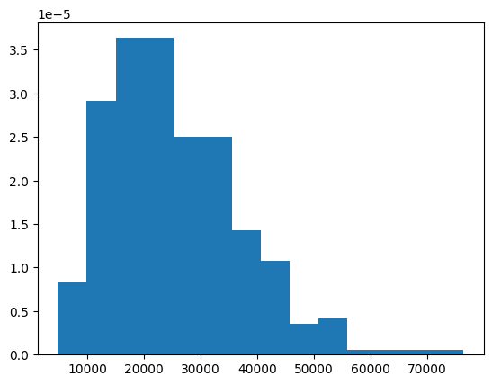

```python
plt.hist(df.quantity, bins = d, density = True)
plt.show()
```

```python
_, d2 = pd.qcut(df['quantity'], 15, retbins=True)
_, d2
```

```
(0       (13249.8, 15210.2]
 1       (18981.0, 20815.2]
 2       (15210.2, 16935.6]
 3       (10983.6, 13249.8]
 4       (22701.0, 23743.6]
               ...
 323     (18981.0, 20815.2]
 324     (13249.8, 15210.2]
 325     (15210.2, 16935.6]
 326     (10983.6, 13249.8]
 327    (4809.999, 10983.6]
 Name: quantity, Length: 328, dtype: category
 Categories (15, interval[float64, right]): [(4809.999, 10983.6] < (10983.6, 13249.8] < (13249.8, 15210.2] < (15210.2, 16935.6] ... (31249.4, 34756.4] < (34756.4, 37903.2] < (37903.2, 43857.2] < (43857.2, 76407.0]],
 array([ 4810. , 10983.6, 13249.8, 15210.2, 16935.6, 18981. , 20815.2,
        22701. , 23743.6, 26705.4, 29221. , 31249.4, 34756.4, 37903.2,
        43857.2, 76407. ]))
```

**[**In here I tried to divide insted by percentile, using equally frequency distri. Although, we notice some damage in the graph, with a very high peak that breaks the relevance of the graph**]**

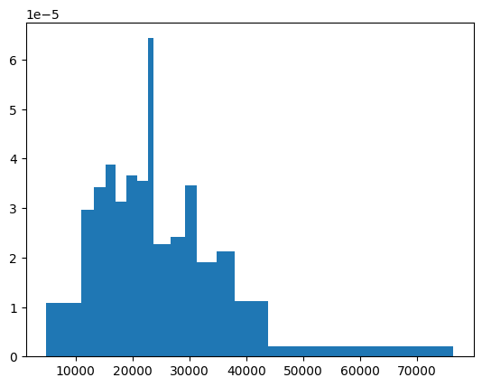

```python
plt.hist(df.quantity, bins = d2, density = True)
plt.show()
```

```python
#From getting equal sized intervals, to some well distributed intervals
d3 = [ 4810.        ,  9924.07142857, 12700.        , 15038.14285714,
        17500.        , 20152.21428571, 22500.        , 24266.28571429, 27250 ,
        29880.35714286, 31900, 35494.42857143, 40608.5       , 43722.57142857,
        50836.64285714, 76407.        ]

ni, bins = np.histogram(df['quantity'], d3)
ni, bins
```

```
(array([14, 24, 25, 32, 29, 28, 28, 21, 23, 21, 24, 24, 11, 13, 11]),
 array([ 4810.        ,  9924.07142857, 12700.        , 15038.14285714,
        17500.        , 20152.21428571, 22500.        , 24266.28571429,
        27250.        , 29880.35714286, 31900.        , 35494.42857143,
        40608.5       , 43722.57142857, 50836.64285714, 76407.        ]))
```

**[**Finally I made a hybrid style of intervals, to get the sweetpoint of 15 classes and ni > 5 in each class**]**

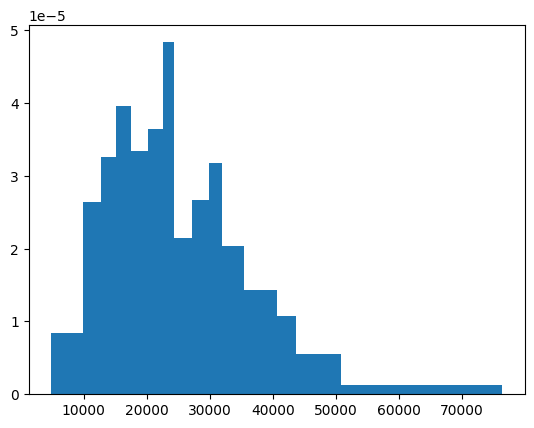

```python
plt.hist(df.quantity, bins = d3, density = True)
plt.show()
```

2. Import the module `seaborn` as `sns` and plot two histograms of the variable `quantity` according to the variable `cartel` by using the following command:

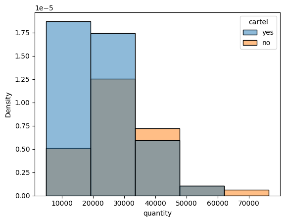

```python
sns.histplot(data = df, x = 'quantity', hue = 'cartel', bins = 5, stat = 'density')
plt.show()
```

### **we use this type of histo to get a class division, and compare values based on some categorical values that makes as categories.**

3. Plot two boxplots of the variable `quantity` according to the variable `cartel` by using the following command:

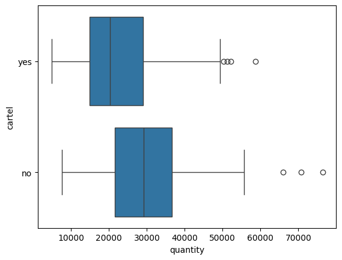

```python
sns.boxplot(data = df, x = 'quantity' , y = 'cartel', orient = 'horizontal')
plt.show()
```

### **We plot a boxplot in horizontal taking into account the values in the x and y axis.**

### Variance decomposition

4. Interpret the following methods for the calculus of the variance of `df.quantity`.

```python
N = len(df.quantity)
np.var(df.quantity), df.quantity.var()*(N-1)/N, df.quantity.var(ddof = 0)
```

```
(np.float64(134908685.8056867),
 np.float64(134908685.8056867),
 np.float64(134908685.8056867))
```

**In the first method we use the numpy for variance assuming we have the data of population. In the second we use the one for samples, but we have to modify it so we divide by the correct amount. The last one by using ddof in pandas we are using the correct number in the denominator by subtracting N-0.**

5. The variance decomposition of the variable `quantity` according to the levels of the variable `cartel` relies on the calculus of the mean and variance of `quantity` inside each level of `cartel`. These calculus can be done manually or by using the `groupby` method of `pandas`. Exexcute and interpret the 4 following cells.

```python
mi = df.groupby('cartel').mean()
mi
```

| cartel | quantity |
| --- | --- |
| no | 29986.416000 |
| yes | 22550.635468 |

**Here we have the intraclass mean, which means the mean in each category**

```python
si2 = df.groupby('cartel').var(ddof = 0)
si2
```

| cartel | quantity |
| --- | --- |
| no | 1.486583e+08 |
| yes | 1.053710e+08 |

**Here it´s the variance of each category, with ddof=0 bc were using a population not a sample**

```python
df.cartel.value_counts()
```

```
cartel
yes    203
no     125
Name: count, dtype: int64
```

```python
ni = df.groupby('cartel').count()
ni
```

| cartel | quantity |
| --- | --- |
| no | 125 |
| yes | 203 |

6. Compute the inter and intra-class variance of `quantity` according to `cartel`. Verify the relation of the decompostion of variance.

```python
n_total = len(df)
global_mean = df['quantity'].mean()
global_var = df['quantity'].var(ddof=0)
```

**we get the main of mean and variance, alongside the amount in each category**

```python
group_stats = df.groupby('cartel')['quantity'].agg(
    n_k='count',
    mean_k='mean',
    var_k=lambda x: x.var(ddof=0)
).reset_index()

print(group_stats)
```

```
  cartel  n_k        mean_k         var_k
0     no  125  29986.416000  1.486583e+08
1    yes  203  22550.635468  1.053710e+08
```

**Here we retrieve the values of each category, the mean and variance, to compute the inter and intra class variance**

```python
inter_variance = (group_stats['n_k'] * (group_stats['mean_k'] - global_mean)**2).sum() / n_total

inter_variance
```

```
np.float64(13041017.856318941)
```

```python
intra_variance = (group_stats['n_k'] * group_stats['var_k']).sum() / n_total

intra_variance
```

```
np.float64(121867667.9493678)
```

**we jut compute based on the formula of the inter and intra class variance**

7. Compute the empirical correlation ratio of `quantity` given `cartel` and interpret it.

```python
correlation_ratio = inter_variance / global_var

print(correlation_ratio)
```

```
0.09666551696383979
```

#### **with this value of 0.096 aprox. we can say that the category cartel has an impact on the variable quantity, however is not determinant on the variable meaning that, there should be other variables that had impact on the variable quantity**